# N741 - Data Wrangling - learning dplyr and more tidyverse packages

Melinda Higgins

2/1/2022

## Load the `Davis` dataset from the `carData` package

```r
# load the carData package
# we'll work with the Davis dataset
# which is a part of this package

library(carData)
data(Davis)
```

## Take a quick look at the `Davis` dataset

Load the `tibble` package and use the `glimpse()` function to take a quick peek at the `Davis` dataset.

The `Davis` dataset has 200 rows and 5 columns. The subjects were men and women engaged in regular exercise. There are some missing data. The 5 variables are:

- sex
  - a factor variable with 2 levels for F, female and M, male
- weight
  - a numeric variable for **measured** weight in kg
- height
  - a numeric variable for **measured** height in cm
- repwt
  - a numeric variable for **self-reported** weight in kg
- repht
  - a numeric variable for **self-reported** height in cm

To learn more about this dataset run `help(Davis, package = "carData")`.

```r
library(tibble)
glimpse(Davis)
```

```
## Rows: 200
## Columns: 5
## $ sex    <fct> M, F, F, M, F, M, M, M, M, M, M, F, F, F, F, F, M, F, M, F, M, ~
## $ weight <int> 77, 58, 53, 68, 59, 76, 76, 69, 71, 65, 70, 166, 51, 64, 52, 65~
## $ height <int> 182, 161, 161, 177, 157, 170, 167, 186, 178, 171, 175, 57, 161,~
## $ repwt  <int> 77, 51, 54, 70, 59, 76, 77, 73, 71, 64, 75, 56, 52, 64, 57, 66,~
## $ repht  <int> 180, 159, 158, 175, 155, 165, 165, 180, 175, 170, 174, 163, 158~
```

## Compute BMI from measured `height` and `weight`

The equation for BMI is

$$BMI = \frac{weight (kg)}{[height (m)]^2}$$

To compute BMI we need to:

1. convert `height` in cm to m
2. then compute BMI

So, let’s add 2 new variables to our dataset using the `mutate()` function from the `dplyr` package.

```r
# load dplyr package
library(dplyr)

Davis2 <- Davis %>%
  mutate(height_m = height/100) %>%
  mutate(bmi = weight / ((height_m)^2))
```

## BMI histograms by `sex`

Let’s try out the `ggpubr` package and use the `ggdensity()` function.

Learn more at https://rpkgs.datanovia.com/ggpubr/.

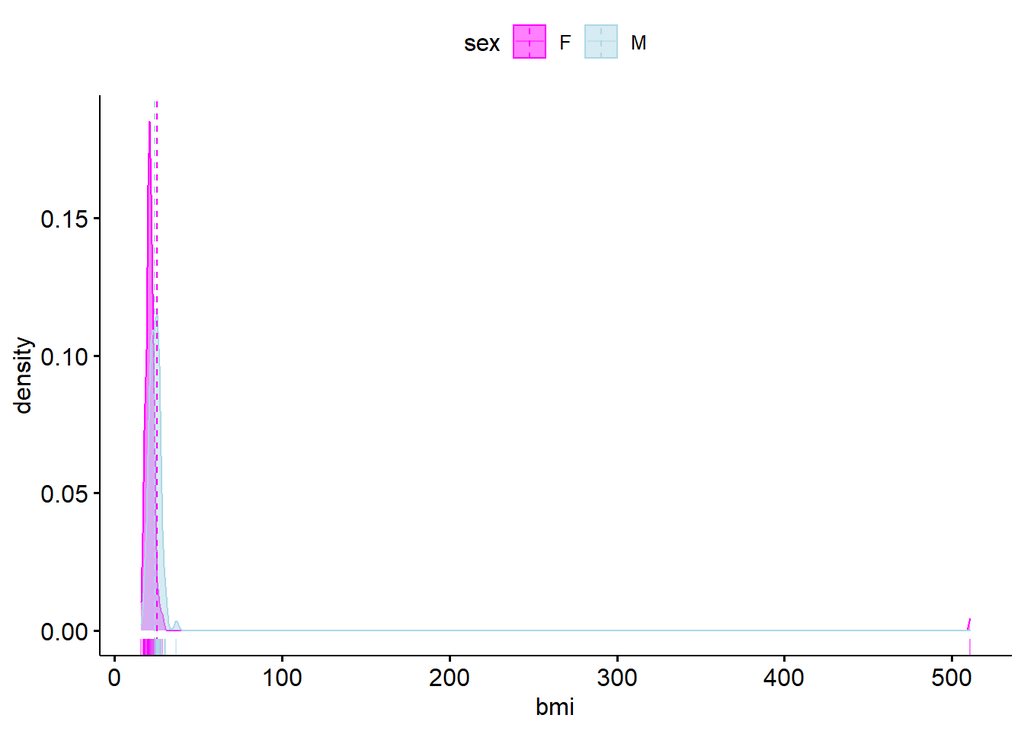

```r
library(ggpubr)
ggdensity(Davis2, x = "bmi",
   add = "mean", rug = TRUE,
   color = "sex", fill = "sex",
   palette = c("magenta", "light blue"))
```

Well this looks odd. I’m guessing there is an outlier somewhere. We could open the data and look at it in a viewer, but let’s try to do it with code.

The `dplyr` package also has an `arrange()` function. So, let’s sort the data and see if we can spot which case has the really large BMI value.

The default is to arrange (or sort) the rows in ascending order. But we want to see the largest value, so we’ll add `desc()` to get the descending sorted order.

```r
Davis2 %>%
  arrange(desc(bmi)) %>%
  head()
```

|  | sex | weight | height | repwt | repht | height_m | bmi |
| --- | --- | --- | --- | --- | --- | --- | --- |
| 12 | F | 166 | 57 | 56 | 163 | 0.57 | 510.92644 |
| 21 | M | 119 | 180 | 124 | 178 | 1.80 | 36.72840 |
| 30 | M | 101 | 183 | 100 | 180 | 1.83 | 30.15916 |
| 97 | M | 103 | 185 | 101 | 182 | 1.85 | 30.09496 |
| 54 | M | 102 | 185 | 107 | 185 | 1.85 | 29.80278 |
| 192 | M | 89 | 173 | 86 | 173 | 1.73 | 29.73704 |

If I had to guess, it looks like the measured height and weight were flipped for case 12. But for now let’s filter this case out and remake our plot.

So, we’ll use the `filter()` function also from `dplyr` package.

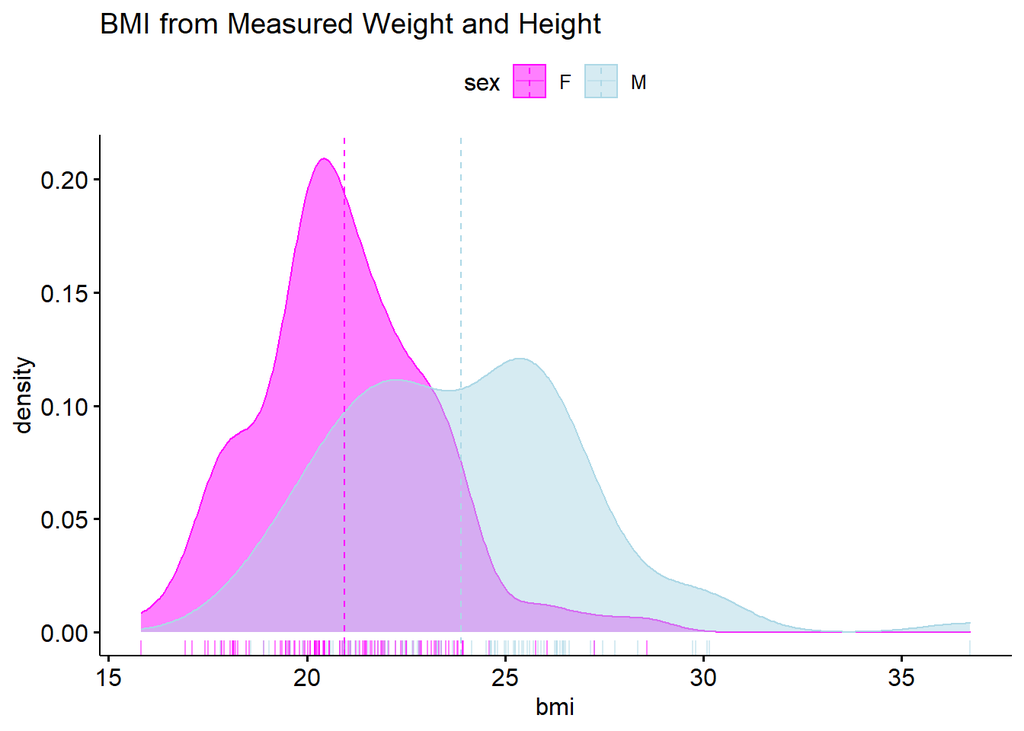

```r
Davis3 <- Davis2 %>%
  filter(bmi < 50)

ggdensity(Davis3, x = "bmi",
   add = "mean", rug = TRUE,
   color = "sex", fill = "sex",
   palette = c("magenta", "light blue")) +
  ggtitle("BMI from Measured Weight and Height")
```

## Get summary statistics of weight, height and bmi

Let’s get the mean for weight, height and bmi

```r
Davis3 %>%
  summarise(across(c(weight, height, bmi),
            ~ mean(.x, na.rm = TRUE))
  )
```

| weight | height | bmi |
| --- | --- | --- |
| 65.29648 | 170.5879 | 22.25761 |

Add `group_by()` to get the means by `sex`

```r
Davis3 %>%
  group_by(sex) %>%
  summarise(across(c(weight, height, bmi),
            ~ mean(.x, na.rm = TRUE))
  )
```

| sex | weight | height | bmi |
| --- | --- | --- | --- |
| F | 56.89189 | 164.7027 | 20.95632 |
| M | 75.89773 | 178.0114 | 23.89901 |

## This is easier with `get_summary_stats()` from `rstatix` package

Let’s try this again and get more stats.

First use the `select()` function from `dplyr` and then get the summary stats.

```r
library(rstatix)

Davis3 %>%
  select(weight, height, bmi) %>%
  get_summary_stats()
```

| variable | n | min | max | median | q1 | q3 | iqr | mad | mean | sd | se | ci |
| --- | --- | --- | --- | --- | --- | --- | --- | --- | --- | --- | --- | --- |
| bmi | 199 | 15.822 | 36.728 | 21.799 | 20.223 | 23.936 | 3.713 | 2.552 | 22.258 | 3.009 | 0.213 | 0.421 |
| height | 199 | 148.000 | 197.000 | 170.000 | 164.000 | 177.500 | 13.500 | 10.378 | 170.588 | 8.949 | 0.634 | 1.251 |
| weight | 199 | 39.000 | 119.000 | 63.000 | 55.000 | 73.500 | 18.500 | 11.861 | 65.296 | 13.343 | 0.946 | 1.865 |

Let’s just get mean and sd (standard deviation) and add `group_by()` to get the stats by `sex`. *NOTE: Add `sex` to the `select()` step.*

```r
Davis3 %>%
  group_by(sex) %>%
  select(sex, weight, height, bmi) %>%
  get_summary_stats(type = "mean_sd")
```

| sex | variable | n | mean | sd |
| --- | --- | --- | --- | --- |
| F | bmi | 111 | 20.956 | 2.176 |
| F | height | 111 | 164.703 | 5.683 |
| F | weight | 111 | 56.892 | 6.891 |
| M | bmi | 88 | 23.899 | 3.120 |
| M | height | 88 | 178.011 | 6.441 |
| M | weight | 88 | 75.898 | 11.890 |

## Compare measured vs self-report heights and weights by sex

I’ve often heard a saying that “women weigh less and men are taller on paper”. But let’s take a look at the discrepancies between the directly measures `height` and `weight` to the self-reports `repwt` and `repht` - overall and by `sex.`

```r
Davis3 <- Davis3 %>%
  mutate(diff_wt_repwt = weight - repwt) %>%
  mutate(diff_ht_repht = height - repht)
```

Now that we’ve computed these differences, let’s look at these differences by sex. Differences < 0 indicate that the self-reported `repwt` or `repht` were larger than the measured `weight` or `height.`

Let’s keep using the `ggpubr` package and try the `ggboxplot()` function and add a reference line, a title and a subtitle using functions from `ggplot2` package which is loaded with `ggpubr`. We’ll also clean up the x-axis and y-axis labels.

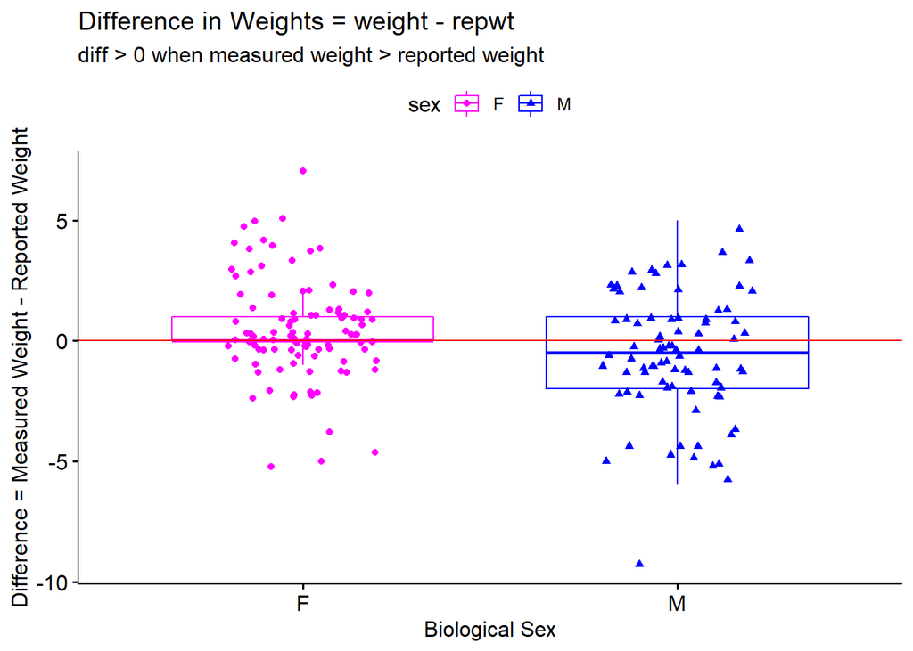

```r
ggboxplot(Davis3, x = "sex", y = "diff_wt_repwt",
                color = "sex",
                palette =c("magenta", "blue"),
                add = "jitter", shape = "sex") +
  geom_hline(yintercept = 0, color = "red") +
  labs(title = "Difference in Weights = weight - repwt",
       subtitle = "diff > 0 when measured weight > reported weight") +
  xlab("Biological Sex") +
  ylab("Difference = Measured Weight - Reported Weight")
```

It looks like for females, their actual weights are larger than their self-reported weights.

Let’s take a look at the differences in the heights.

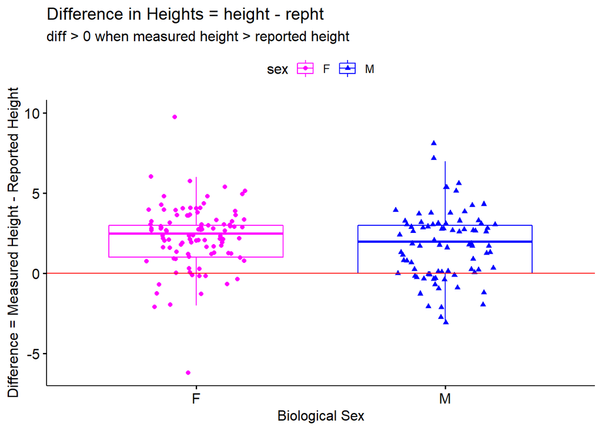

```r
ggboxplot(Davis3, x = "sex", y = "diff_ht_repht",
                color = "sex",
                palette =c("magenta", "blue"),
                add = "jitter", shape = "sex") +
  geom_hline(yintercept = 0, color = "red") +
  labs(title = "Difference in Heights = height - repht",
       subtitle = "diff > 0 when measured height > reported height")  +
  xlab("Biological Sex") +
  ylab("Difference = Measured Height - Reported Height")
```

From this plot it looks like the measured heights are higher than the self-reported heights for both females and males.

Get summary stats of these differences by `sex`.

```r
Davis3 %>%
  group_by(sex) %>%
  select(sex, diff_wt_repwt, diff_ht_repht) %>%
  get_summary_stats(type = "mean_sd")
```

| sex | variable | n | mean | sd |
| --- | --- | --- | --- | --- |
| F | diff_ht_repht | 100 | 2.330 | 2.000 |
| F | diff_wt_repwt | 100 | 0.480 | 2.062 |
| M | diff_ht_repht | 82 | 1.756 | 2.146 |
| M | diff_wt_repwt | 82 | -0.585 | 2.489 |